# Case Study 2 - MAP566

## 1. Fitting a linear model

### 1.1 Plot the data

```r
data <- read.csv("/Users/haliouanaomie/PolytechniqueS2/MAP566/salesData/sales1.csv")
head(data)
```

|  | time | y |
| --- | --- | --- |
| 1 | 1 | 101.82562 |
| 2 | 4 | 103.16069 |
| 3 | 7 | 99.48002 |
| 4 | 10 | 103.25016 |
| 5 | 13 | 106.46870 |
| 6 | 16 | 108.53795 |

```r
summary(data)
```

```
      time          y
 Min.   : 1   Min.   : 99.48
 1st Qu.:16   1st Qu.:106.47
 Median :31   Median :110.42
 Mean   :31   Mean   :111.77
 3rd Qu.:46   3rd Qu.:116.83
 Max.   :61   Max.   :125.07
```

```r
dim(data)
```

```
[1] 21  2
```

The data consists of 21 observations (rows) and 2 variables (columns): time and the quarterly sales volumes in percentage y.

Let’s scatter plot the data in order to better visualize the relationship between the explanatory variable and the response variable.

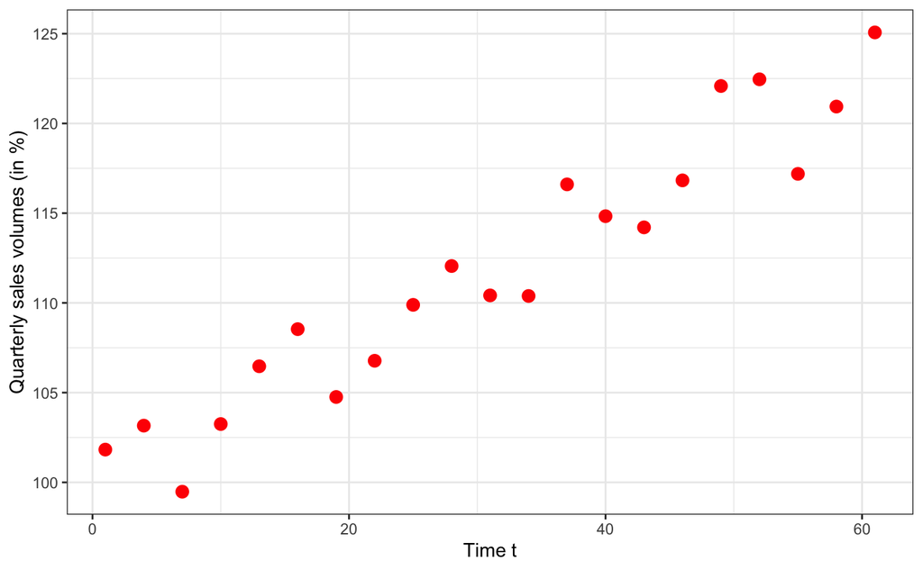

```r
library(ggplot2)
theme_set(theme_bw())
pl <- ggplot(data=data) + geom_point(aes(x=time,y=y), color="red", size=3) + xlab("Time t") + ylab("Quarterly sales volumes (in %)")
pl
```

We easily observe on the above scatter plot that there is a clear increasing trend in our data. It suggests a linearly increasing relationship between the explanatory and response variables.

### 1.2 Fit a polynomial model to this data (justify the choice of the degree)

Based on this data, our objective is to fit a polynomial model to this data by building a regression model of the form:
$$y_j = f(x_j) + e_j \quad ; \quad 1 \leq j \leq n$$
where $(xj,1≤j≤n)$ and $(yj,1≤j≤n)$ represent, respectively, the n=21 measured time and quarterly sales volumes and where $(ej,1≤j≤n)$ is a sequence of residual errors. In other words, ej represents the difference between the sale volume predicted by the model f(xj) and the observed sale volume yj.

We will restrict ourselves to polynomial regression, by considering functions of the form

$f(x)=f(x;c0,c1,c2,…,cd)=c0+c1x+c2x2+…+cdxd$

As said earlier, we can easily observe that there is a clear increasing trend in our data. Thus, the function we should be considering is at least of degree 1, and intuitively we can think that the best model will be of degree 1. Let us therefore assume a linear trend and fit a polynomial of degree 1 using the lm function:

**Fitting a polynomial of degree 1**

$yj=c0+c1xj+ej;1≤j≤n$

```r
lm1 <- lm(y ~ time, data=data)
coef(lm1)
```

```
(Intercept)        time
 99.9968826   0.3798515
```

These coefficients are the intercept and the slope of the regression line, but more informative results about this model are available.

```r
summary(lm1)
```

```
Call:
lm(formula = y ~ time, data = data)

Residuals:
    Min      1Q  Median      3Q     Max
-3.6994 -1.5777 -0.3596  1.6444  3.4747

Coefficients:
             Estimate Std. Error t value Pr(>|t|)
(Intercept)  99.99688    0.94971  105.29  < 2e-16 ***
time          0.37985    0.02643   14.37 1.17e-11 ***
---
Signif. codes:  0 ‘***’ 0.001 ‘**’ 0.01 ‘*’ 0.05 ‘.’ 0.1 ‘ ’ 1

Residual standard error: 2.2 on 19 degrees of freedom
Multiple R-squared:  0.9158,    Adjusted R-squared:  0.9113
F-statistic: 206.5 on 1 and 19 DF,  p-value: 1.166e-11
```

The slope `c1` is clearly statistically significant (p-value = 1.17e-11) while the model explains about 91% of the variability of the data. The confidence interval for c1 confirms that an increase of the time leads to a significant increase of the variable y. The residuals are approximately zero.

```r
confint(lm1)
```

```
                 2.5 %      97.5 %
(Intercept) 98.0091258 101.9846394
time         0.3245292   0.4351738
```

The fact that the slope is significantly different from zero does not imply that this polynomial model of degree 1 correctly describes the data: at this stage, we can only conclude that a polynomial of degree 1 better explains the variability of the data than a constant model.

Diagnostic plots are visual tools that allows one to see if something is not right between a chosen model and the data it is hypothesized to describe.

First, we can add the regression line to the plot of the data.

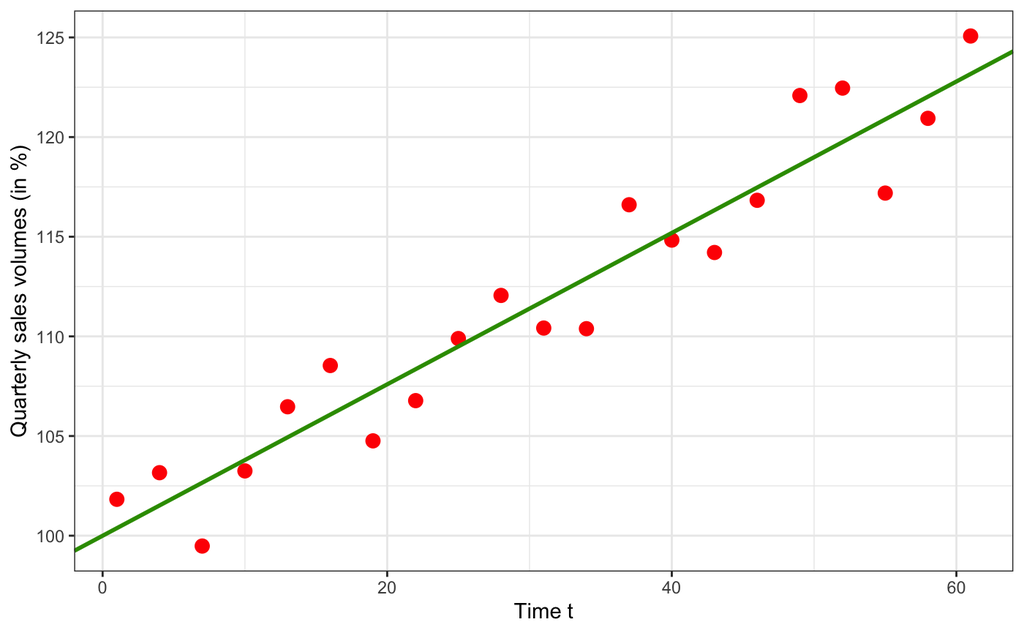

```r
pl  + geom_abline(intercept=coef(lm1)[1],slope=coef(lm1)[2],size=1, colour="#339900")
```

The regression line decribes pretty well the global trend in the data: based on this graphic, there is no reason to reject the model. Several diagnotic plots are available for a lm object. The first two are a plot of residuals against fitted values and a normal QQ plot.

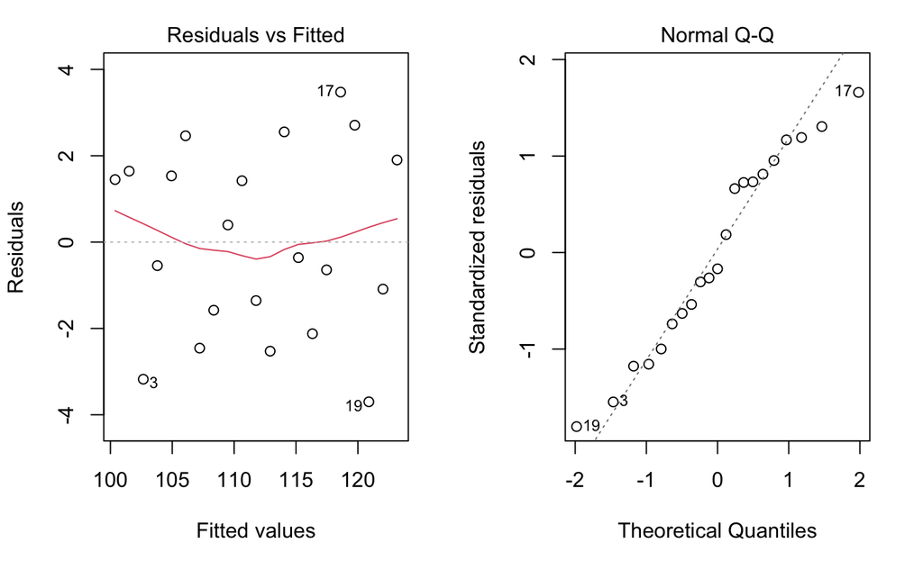

```r
par(mfrow = c(1, 2))
plot(lm1, which=c(1,2))
```

The residual plot shows a slight (decreasing and increasing) trend which suggests that the residuals are not identically distributed around 0. Furthermore, the QQ plot shows that the extreme residual values are not the extreme values of a normal distribution. It may be therefore necessary to improve the regression model.

**Fitting a polynomial of degree 2**

We can expect to better describe the extreme values by using a polynomial of higher degree. Let us therefore fit a polynomial of degree 2 to the data. $yj=c0+c1xj+c2x2j+ej;1≤j≤n$

```r
lm2 <- lm (y ~  time + I(time^2), data =data)
summary(lm2)
```

```
Call:
lm(formula = y ~ time + I(time^2), data = data)

Residuals:
    Min      1Q  Median      3Q     Max
-3.9334 -1.4679 -0.1228  1.5395  3.4804

Coefficients:
             Estimate Std. Error t value Pr(>|t|)
(Intercept) 1.006e+02  1.426e+00  70.521  < 2e-16 ***
time        3.209e-01  1.065e-01   3.013  0.00747 **
I(time^2)   9.511e-04  1.662e-03   0.572  0.57422
---
Signif. codes:  0 ‘***’ 0.001 ‘**’ 0.01 ‘*’ 0.05 ‘.’ 0.1 ‘ ’ 1

Residual standard error: 2.24 on 18 degrees of freedom
Multiple R-squared:  0.9173,    Adjusted R-squared:  0.9081
F-statistic: 99.77 on 2 and 18 DF,  p-value: 1.818e-10
```

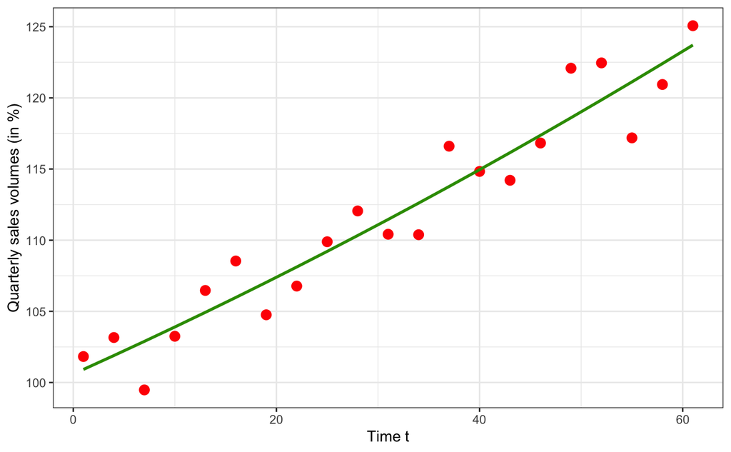

```r
pl  + geom_line(aes(x=time, y=predict(lm2)),size=1, colour="#339900")
```

Again, the regression line decribes pretty well the global trend in the data: based on this graphic, there is no reason to reject the model. Several diagnotic plots are available for a lm object. The first two are a plot of residuals against fitted values and a normal QQ plot.

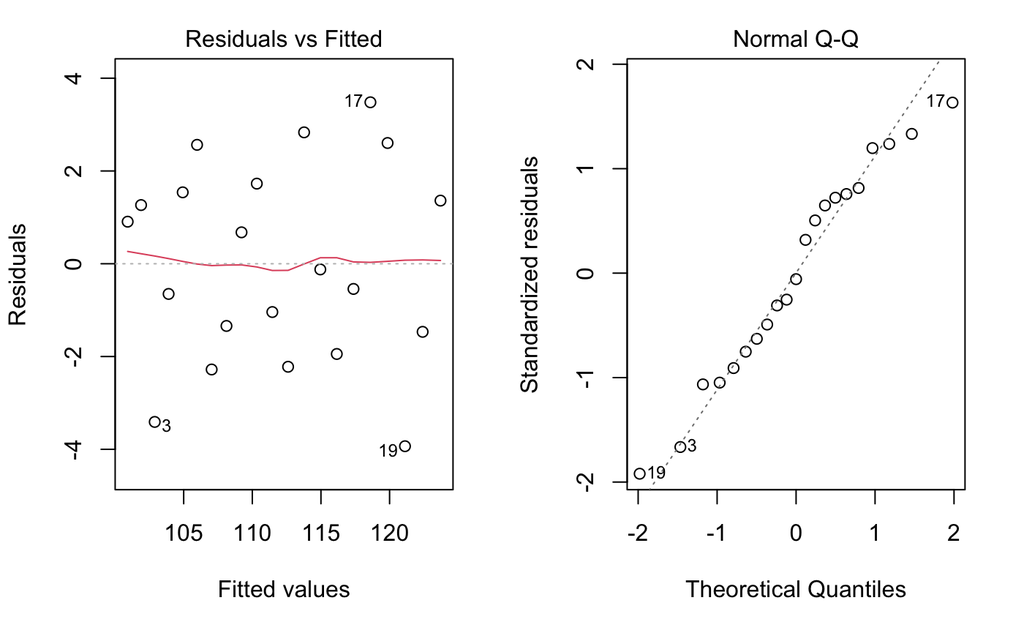

```r
par(mfrow = c(1, 2))
plot(lm2, which=c(1,2))
```

The residual plot shows a linear trend which suggests that the residuals are identically distributed around 0. Furthermore, the QQ plot shows that the extreme residual values are not the extreme values of a normal distribution. It may be therefore necessary to improve the regression model.

**Fitting a polynomial of degree 5**

```r
lm6 <- lm(y ~ poly(time, degree=5), data=data)
summary(lm6)
```

```
Call:
lm(formula = y ~ poly(time, degree = 5), data = data)

Residuals:
    Min      1Q  Median      3Q     Max
-3.8282 -1.3464 -0.3117  1.6405  3.4688

Coefficients:
                         Estimate Std. Error t value Pr(>|t|)
(Intercept)             111.77228    0.53270 209.823  < 2e-16 ***
poly(time, degree = 5)1  31.62136    2.44113  12.954 1.51e-09 ***
poly(time, degree = 5)2   1.28207    2.44113   0.525    0.607
poly(time, degree = 5)3  -0.74968    2.44113  -0.307    0.763
poly(time, degree = 5)4   0.62850    2.44113   0.257    0.800
poly(time, degree = 5)5  -0.04827    2.44113  -0.020    0.984
---
Signif. codes:  0 ‘***’ 0.001 ‘**’ 0.01 ‘*’ 0.05 ‘.’ 0.1 ‘ ’ 1

Residual standard error: 2.441 on 15 degrees of freedom
Multiple R-squared:  0.9181,    Adjusted R-squared:  0.8908
F-statistic: 33.65 on 5 and 15 DF,  p-value: 1.225e-07
```

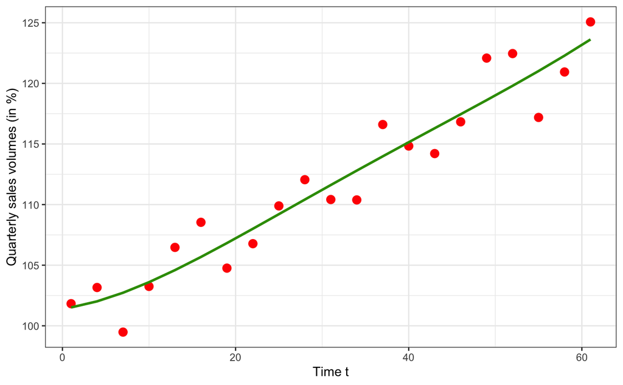

```r
pl  + geom_line(aes(x=time, y=predict(lm6)),size=1, colour="#339900")
```

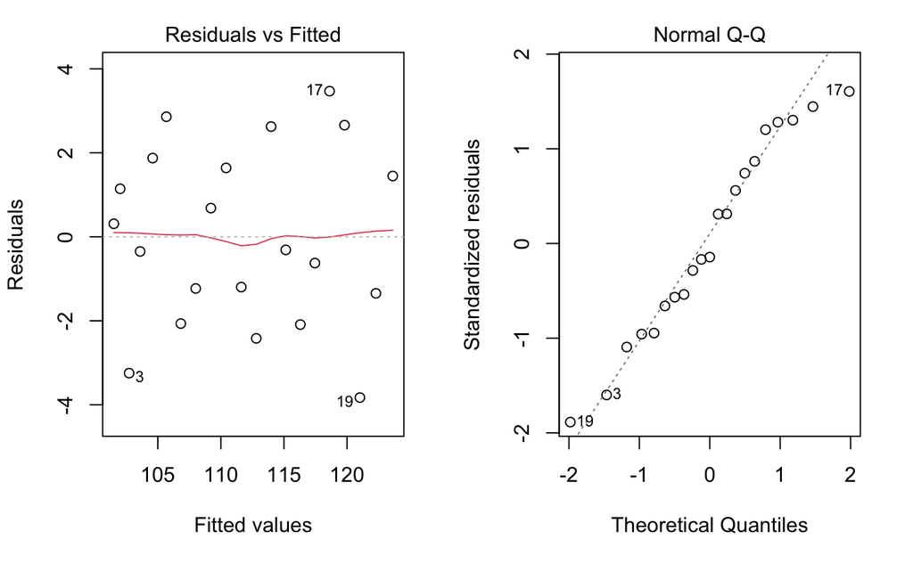

```r
par(mfrow = c(1, 2))
plot(lm6, which=c(1,2))
```

We use **the Bayesian information criaterion (BIC)** for comparing models which are not necessarily nested.

```r
BIC(lm0,lm1,lm2,lm6)
```

|  | df | BIC |
| --- | --- | --- |
| lm0 | 2 | 148.6587 |
| lm1 | 3 | 99.7492 |
| lm2 | 4 | 102.4151 |
| lm6 | 7 | 111.3245 |

```r
AIC(lm0,lm1,lm2,lm6)
```

|  | df | AIC |
| --- | --- | --- |
| lm0 | 2 | 146.56961 |
| lm1 | 3 | 96.61563 |
| lm2 | 4 | 98.23700 |
| lm6 | 7 | 104.01281 |

Models with lowest BIC and AIC are preferred. Here, both criteria agree for rejecting lm0 with high confidence. Both BIC and AIC has a very slight preference for lm1 and lm2. Nevertheless, these differences are not large enough for selecting definitely any of these 2 models.

### 1.3 Try to improve the model by adding a periodic component

```r
lin_mod_per <- lm(y ~ time + (cos((2*pi)*time/3)) + (sin((2*pi)*time/3)), data=data)
summary(lin_mod_per)
```

```
Call:
lm(formula = y ~ time + (cos((2 * pi) * time/3)) + (sin((2 *
    pi) * time/3)), data = data)

Residuals:
    Min      1Q  Median      3Q     Max
-3.6994 -1.5777 -0.3596  1.6444  3.4747

Coefficients: (2 not defined because of singularities)
                        Estimate Std. Error t value Pr(>|t|)
(Intercept)             99.99688    0.94971  105.29  < 2e-16 ***
time                     0.37985    0.02643   14.37 1.17e-11 ***
cos((2 * pi) * time/3)        NA         NA      NA       NA
sin((2 * pi) * time/3)        NA         NA      NA       NA
---
Signif. codes:  0 ‘***’ 0.001 ‘**’ 0.01 ‘*’ 0.05 ‘.’ 0.1 ‘ ’ 1

Residual standard error: 2.2 on 19 degrees of freedom
Multiple R-squared:  0.9158,    Adjusted R-squared:  0.9113
F-statistic: 206.5 on 1 and 19 DF,  p-value: 1.166e-11
```

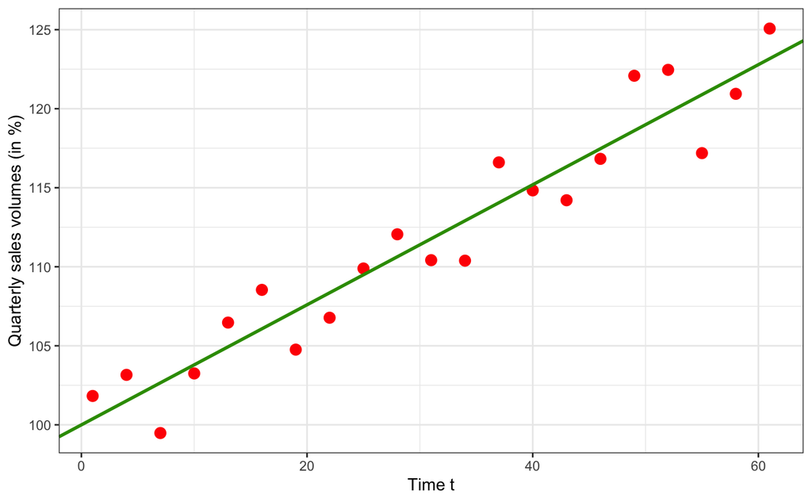

```r
pl + geom_abline(intercept=coef(lin_mod_per)[1], slope=coef(lin_mod_per)[2], size=1, colour="#339900")
```

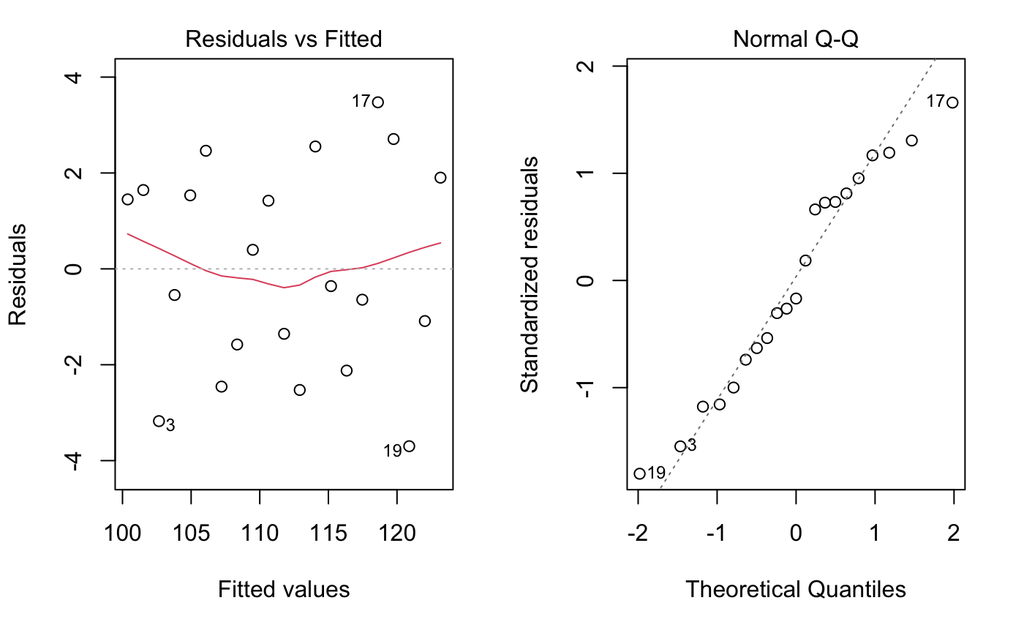

```r
par(mfrow = c(1, 2))
plot(lin_mod_per, which=c(1,2))
```

###1.4 Plot on a same graph the observed sales together with the predicted sales given by your final model. What do you think about this model? What about the residuals?

A common practice is to split the dataset into a 80:20 sample (training:test), then, build the model on the 80% sample and then use the model thus built to predict the reponse variable on test data. Doing it this way, we will have the model predicted values for the 20% data (test). We can then see how the model will perform with this ``new’’ data, by comparing these predicted values with the original ones. We can alo check the stability of the prediction given by the model, by comparing these predicted values with those obtained previouly, when the complete data were used for building the model. Let us first randomly define the training and test samples:

```r
set.seed(100)
n <- nrow(data)
i.training <- sort(sample(n,round(n*0.8)))
data.training <- data[i.training,]
data.test <- data[-i.training,]

pred1a.test <- predict(lm6, newdata=data.test)

lm6.training <- lm(y ~ poly(time, degree=2), data=data.training)
pred1b.test <- predict(lm6.training, newdata=data.test)


data.frame(data.test, pred1a.test, pred1b.test)
```

|  | time | y | pred1a.test | pred1b.test |
| --- | --- | --- | --- | --- |
| 1 | 1 | 101.8256 | 101.5153 | 100.2970 |
| 5 | 13 | 106.4687 | 104.5944 | 104.4941 |
| 11 | 31 | 110.4174 | 111.6145 | 111.2312 |
| 13 | 37 | 116.6042 | 113.9796 | 113.5946 |

```r
y.test <- data.test$y
par(mfrow=c(1,2))
plot(pred1b.test, y.test)
abline(a=0, b=1, lty=2)
```

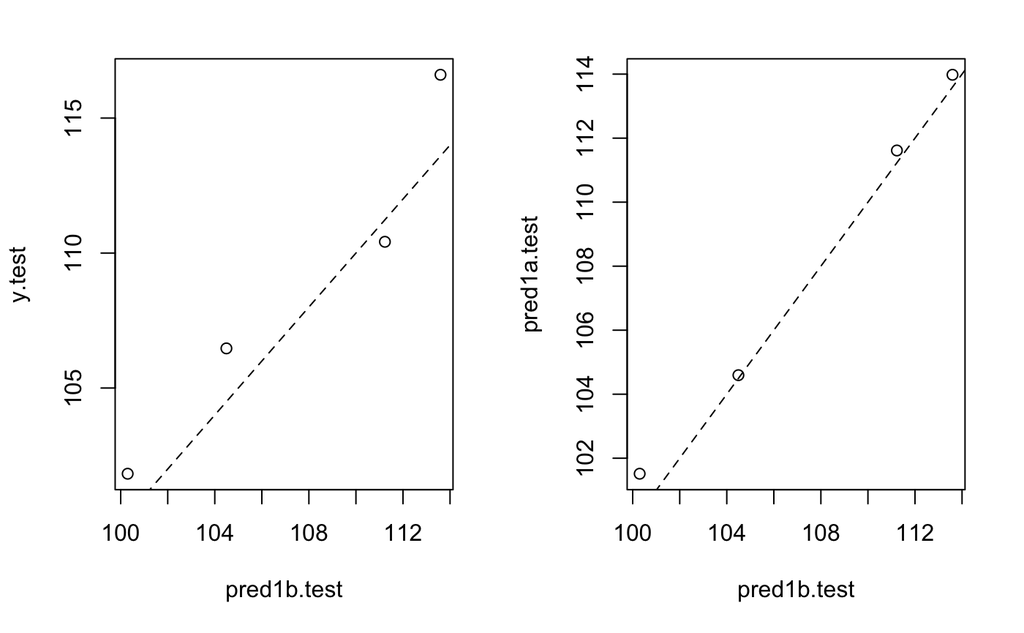

```r
plot(pred1b.test, pred1a.test)
abline(a=0, b=1, lty=2)
```

```r
cor.test <- cor(pred1a.test, y.test)
R2.test <- cor.test^2
R2.test
```

```
[1] 0.9271519
```

## 2 Fitting a linear mixed effects model

```r
sales30 <- read.csv("/Users/haliouanaomie/PolytechniqueS2/MAP566/salesData/sales30.csv")
head(sales30)
```

|  | id | time | y |
| --- | --- | --- | --- |
| 1 | 1 | 1 | 101.82562 |
| 2 | 1 | 4 | 103.16069 |
| 3 | 1 | 7 | 99.48002 |
| 4 | 1 | 10 | 103.25016 |
| 5 | 1 | 13 | 106.46870 |
| 6 | 1 | 16 | 108.53795 |

```r
summary(sales30)
```

```
       id            time          y
 Min.   : 1.0   Min.   : 1   Min.   : 92.32
 1st Qu.: 8.0   1st Qu.:16   1st Qu.:102.03
 Median :15.5   Median :31   Median :105.83
 Mean   :15.5   Mean   :31   Mean   :106.87
 3rd Qu.:23.0   3rd Qu.:46   3rd Qu.:111.17
 Max.   :30.0   Max.   :61   Max.   :129.44
```

```r
dim(sales30)
```

```
[1] 630   3
```

Let us plot the data, i.e. the time versus y by id:

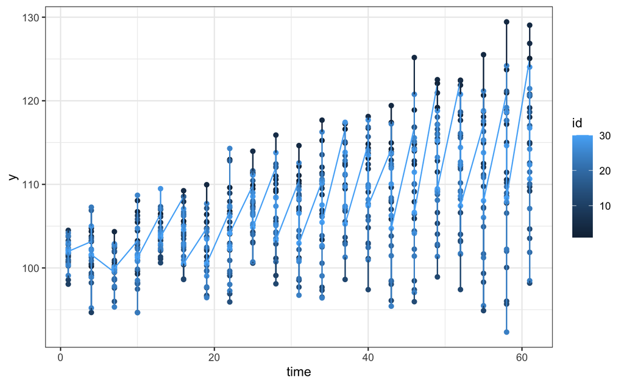

```r
library(ggplot2)
theme_set(theme_bw())
pl <- ggplot(data=sales30, aes(x=time,y=y,color=id)) + geom_point() + geom_line()
pl
```

### 2.2 Fit a Linear Model to this data

```r
lm2 <- lm(y~time+id, data=sales30)
summary(lm2)
```

```
Call:
lm(formula = y ~ time + id, data = sales30)

Residuals:
     Min       1Q   Median       3Q      Max
-19.1537  -2.8850   0.2436   3.2400  15.2073

Coefficients:
             Estimate Std. Error t value Pr(>|t|)
(Intercept) 102.37837    0.56724 180.486  < 2e-16 ***
time          0.21383    0.01170  18.271  < 2e-16 ***
id           -0.13768    0.02456  -5.606 3.11e-08 ***
---
Signif. codes:  0 ‘***’ 0.001 ‘**’ 0.01 ‘*’ 0.05 ‘.’ 0.1 ‘ ’ 1

Residual standard error: 5.336 on 627 degrees of freedom
Multiple R-squared:  0.3681,    Adjusted R-squared:  0.3661
F-statistic: 182.6 on 2 and 627 DF,  p-value: < 2.2e-16
```

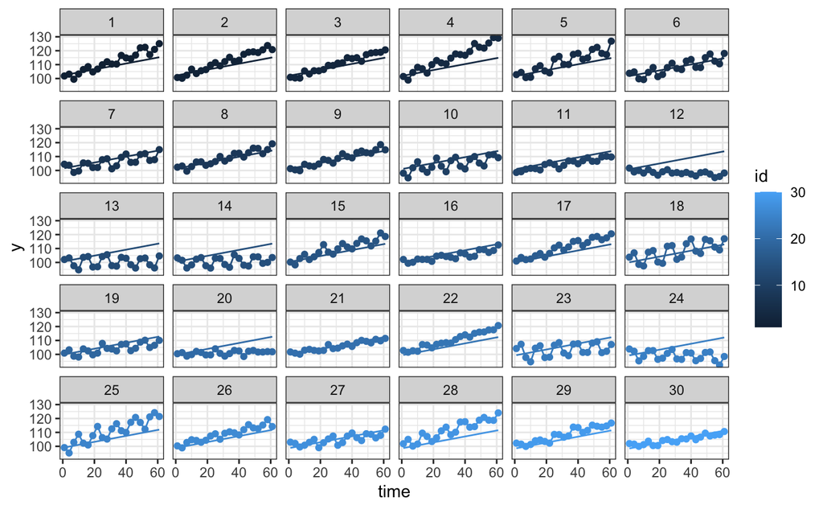

```r
sales30$pred.lm2 <- predict(lm2)
pl + geom_line(data=sales30,aes(x=time,y=pred.lm2)) + facet_wrap(~id)
```

We see that the model seems to underestimate or overestimate the individual data.

### 2.3 Fit a mixed effect model to this data

The model is called linear mixed effects model because it is a linear combination of fixed and random effects. We can use the function lmer for fitting this model. By default, the restricted mximum likelihood (REML) method is used.

```r
library(lme4)
lme1 <- lmer(y ~ time  + (1|id), data=sales30)
summary(lme1)
```

```
Linear mixed model fit by REML ['lmerMod']
Formula: y ~ time + (1 | id)
   Data: sales30

REML criterion at convergence: 3504.2

Scaled residuals:
    Min      1Q  Median      3Q     Max
-3.5631 -0.6545  0.0014  0.6702  3.0473

Random effects:
 Groups   Name        Variance Std.Dev.
 id       (Intercept) 17.50    4.183
 Residual             12.88    3.590
Number of obs: 630, groups:  id, 30

Fixed effects:
             Estimate Std. Error t value
(Intercept) 1.002e+02  8.144e-01  123.09
time        2.138e-01  7.872e-03   27.16

Correlation of Fixed Effects:
     (Intr)
time -0.300
```

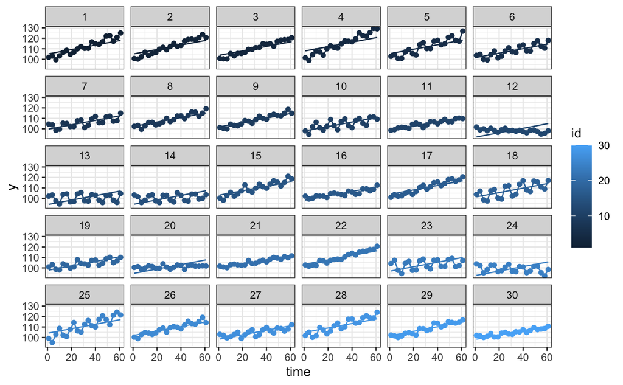

```r
pl + geom_line(aes(x=time,y=predict(lme1),color=id)) + facet_wrap(~id)
```

```r
lme2 <- lmer(y ~ time  + (-1+time|id), data=sales30)
summary(lme2)
```

```
Linear mixed model fit by REML ['lmerMod']
Formula: y ~ time + (-1 + time | id)
   Data: sales30

REML criterion at convergence: 3101.3

Scaled residuals:
     Min       1Q   Median       3Q      Max
-2.56399 -0.72868  0.01628  0.73268  2.76448

Random effects:
 Groups   Name Variance Std.Dev.
 id       time 0.01867  0.1366
 Residual      6.48171  2.5459
Number of obs: 630, groups:  id, 30

Fixed effects:
             Estimate Std. Error t value
(Intercept) 100.24425    0.20062 499.665
time          0.21383    0.02556   8.365

Correlation of Fixed Effects:
     (Intr)
time -0.188
```

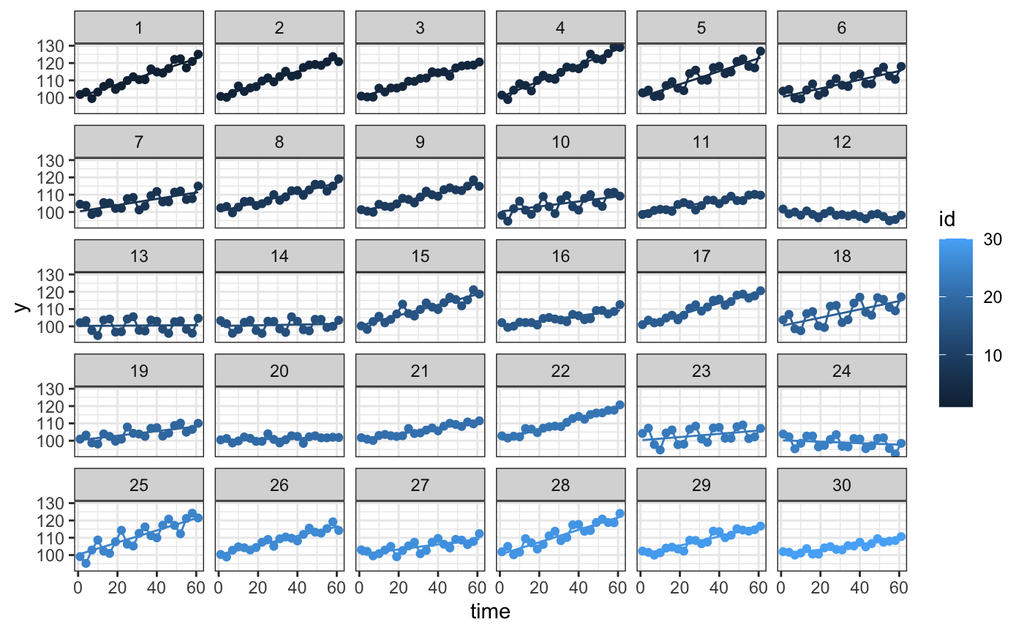

```r
pl + geom_line(aes(x=time,y=predict(lme2),color=id)) + facet_wrap(~id)
```

```r
lme3 <- lmer(y ~ time  + (time|id), data=sales30)
```

```
boundary (singular) fit: see ?isSingular
```

```r
summary(lme3)
```

```
Linear mixed model fit by REML ['lmerMod']
Formula: y ~ time + (time | id)
   Data: sales30

REML criterion at convergence: 3101.3

Scaled residuals:
     Min       1Q   Median       3Q      Max
-2.56400 -0.72869  0.01628  0.73268  2.76449

Random effects:
 Groups   Name        Variance Std.Dev. Corr
 id       (Intercept) 0.00000  0.0000
          time        0.01867  0.1366    NaN
 Residual             6.48165  2.5459
Number of obs: 630, groups:  id, 30

Fixed effects:
             Estimate Std. Error t value
(Intercept) 100.24425    0.20062 499.667
time          0.21383    0.02557   8.364

Correlation of Fixed Effects:
     (Intr)
time -0.188
optimizer (nloptwrap) convergence code: 0 (OK)
boundary (singular) fit: see ?isSingular
```

The warning just indicates that one or more variances are (very close to) zero.

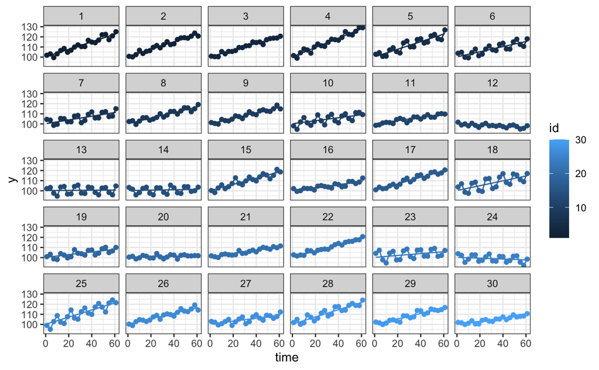

```r
pl + geom_line(aes(x=time,y=predict(lme3),color=id)) + facet_wrap(~id)
```

```r
BIC(lme1,lme2,lme3)
```

|  | df | BIC |
| --- | --- | --- |
| lme1 | 4 | 3530.014 |
| lme2 | 4 | 3127.128 |
| lme3 | 6 | 3140.019 |

```r
AIC(lme1,lme2,lme3)
```

|  | df | AIC |
| --- | --- | --- |
| lme1 | 4 | 3512.231 |
| lme2 | 4 | 3109.345 |
| lme3 | 6 | 3113.345 |

We can compute 95% profile-based confidence intervals for the parameters of the model:

```r
confint(lme2)
```

```
Computing profile confidence intervals ...
```

```
                 2.5 %      97.5 %
.sig01       0.1059332   0.1775463
.sigma       2.4063866   2.6948035
(Intercept) 99.8507370 100.6377687
time         0.1630287   0.2646267
```

Parametric bootstrap can also be used for computing confidence intervals:

```r
confint(lme2,method="boot")
```

```
Computing bootstrap confidence intervals ...
```

```
                  2.5 %      97.5 %
.sig01       0.09752752   0.1746568
.sigma       2.39082393   2.6892572
(Intercept) 99.85471462 100.6319238
time         0.15595288   0.2625349
```

There is only one random effect in the final model. We can plot 95% prediction intervals on the random effects (ηi)

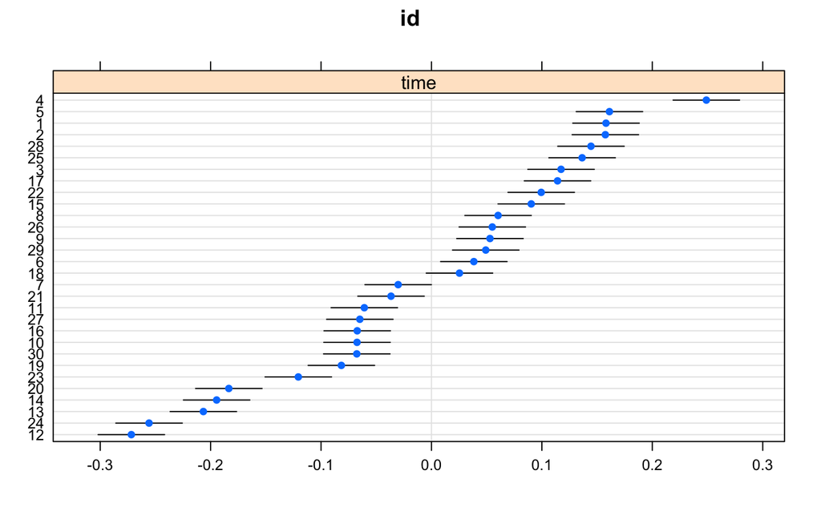

```r
library(lattice)
d = dotplot(ranef(lme2, condVar = TRUE))
print(d[[1]])
```

### 2.4 Plot the data with the predicted sales given by your final model.

Let us plot the predicted time together with the observed time.

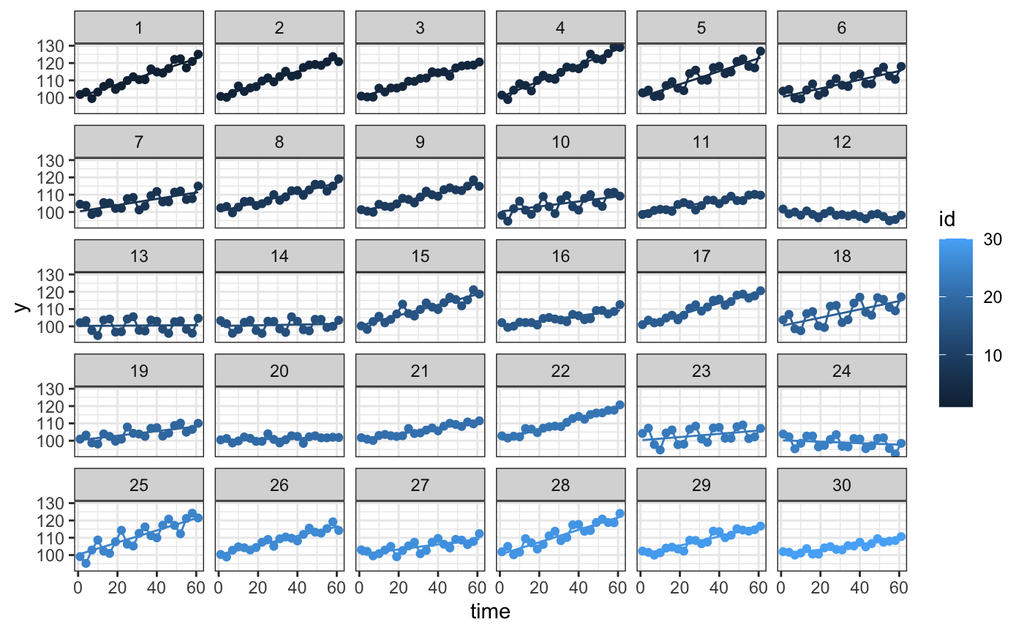

```r
 pl + geom_line(data=sales30 ,aes(x=time,y=predict(lme2))) + facet_wrap(~ id )
```

```r
subset(sales30,id == "2")
```

|  | id | time | y | pred.lm2 |
| --- | --- | --- | --- | --- |
| 22 | 2 | 1 | 100.7274 | 102.3168 |
| 23 | 2 | 4 | 100.1915 | 102.9583 |
| 24 | 2 | 7 | 102.4322 | 103.5998 |
| 25 | 2 | 10 | 106.7346 | 104.2413 |
| 26 | 2 | 13 | 103.5701 | 104.8828 |
| 27 | 2 | 16 | 105.5952 | 105.5242 |
| 28 | 2 | 19 | 106.4030 | 106.1657 |
| 29 | 2 | 22 | 109.6198 | 106.8072 |
| 30 | 2 | 25 | 111.4352 | 107.4487 |
| 31 | 2 | 28 | 109.1279 | 108.0902 |

[output cut: 11 more lines]